# Fall 2024

## MATH 261: Intro to Data Science

### Exam #1 | Total points: 50

### **Thinh Nguyen**

**Due:** Thursday, 10/10/2024 by 11:59pm

### **Important Instructions:**

- **It is mandatory to consistently uphold the DePauw integrity policy,** [DePauw’s Academic Integrity Policy.](https://www.depauw.edu/academics/academic-resources/academic-integrity/)
- **Refrain from utilizing resources like ChatGPT or any other materials that may lead to plagiarism concerns.**
- **Carry out your tasks autonomously and avoid sharing any documents via email or other communication platforms.**
- **Please be aware that appropriate actions will be implemented in case any violation is identified.**
- **Show both your R codes and results in the HTML file.**
- **Save your .RMD file/.HTML file as your Last Name_Exam1_TakeHome.RMD/Last Name_Exam1_TakeHome.HTML**
- **Submit your Exam #1-TakeHome (both .RMD and .HTML files) on Moodle through the appropriate link.**

**Q1** A doctor’s clinic measures the fasting blood sugar level (bsl) of all patients who come in for their annual check ups. In one week, 95 bsl (mg/ml) measures were obtained. A patient who forgot to disclose that he had eaten a bowl of honey roasted cheerios an hour before the blood sample was drawn runs the risk of being falsely classified as diabetic. That’s why they say: “Do not lie to your doctor, or your pastor, or your attorney (or your statistician).” We are, of course, kidding. The correct rule is: “Do not lie.”

[3+7+6+6+3=25 pts.]

The data set `sugar.csv` is linked on Moodle. As needed, categorize the blood sugar level as follows:  
`blood_sugar <=110` is considered as `Low sugar`  
`blood_sugar > 110 but <=140` is considered as `High sugar` and  
`blood_sugar > 140` is considered as`See a doctor`.  
Create the following graphs:

1. A boxplot of blood sugar levels.
2. Dot plots for different blood sugar levels.
3. Boxplots for different blood sugar levels.
4. A bar plot for different blood sugar levels.
5. Write a few sentences summarizing your bar plot.

Refer to the PDF file on Moodle to help replicate your graphs.

```r
# Load necessary libraries
library(ggplot2)
library(dplyr)
sugar_data <- read.csv("sugar.csv")
head(sugar_data)
```

```
##   subject blood_sugar
## 1       1          84
## 2       2          91
## 3       3          97
## 4       4          99
## 5       5          97
## 6       6          96
```

```r
sugar_data <- sugar_data %>%
  mutate(blood_sugar_category = case_when(
    blood_sugar <= 110 ~ "Normal sugar",
    blood_sugar > 110 & blood_sugar < 140 ~ "High sugar",
    blood_sugar >= 140 ~ "See a doctor"
  ))
head(sugar_data)
```

```
##   subject blood_sugar blood_sugar_category
## 1       1          84         Normal sugar
## 2       2          91         Normal sugar
## 3       3          97         Normal sugar
## 4       4          99         Normal sugar
## 5       5          97         Normal sugar
## 6       6          96         Normal sugar
```

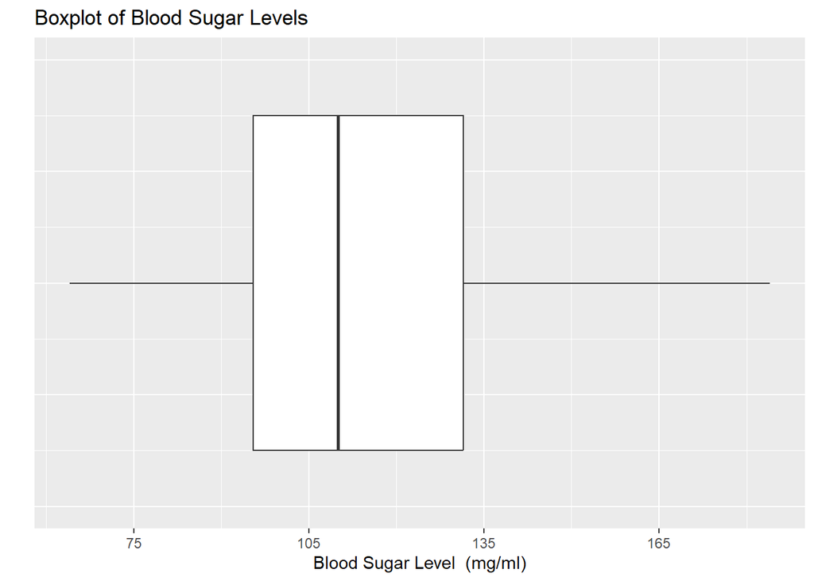

```r
##a. Boxplot of blood sugar levels
ggplot(sugar_data, aes(x = blood_sugar)) +
  geom_boxplot() +
  scale_x_continuous(breaks = seq(75, 195, by = 30))+
  labs(title = "Boxplot of Blood Sugar Levels", x = "Blood Sugar Level  (mg/ml)", y = "")+
  ylim(c(-0.5, 0.5)) +
  theme(axis.text.y = element_blank(),  # Remove y-axis text
        axis.ticks.y = element_blank())  # Remove y-axis ticks
```

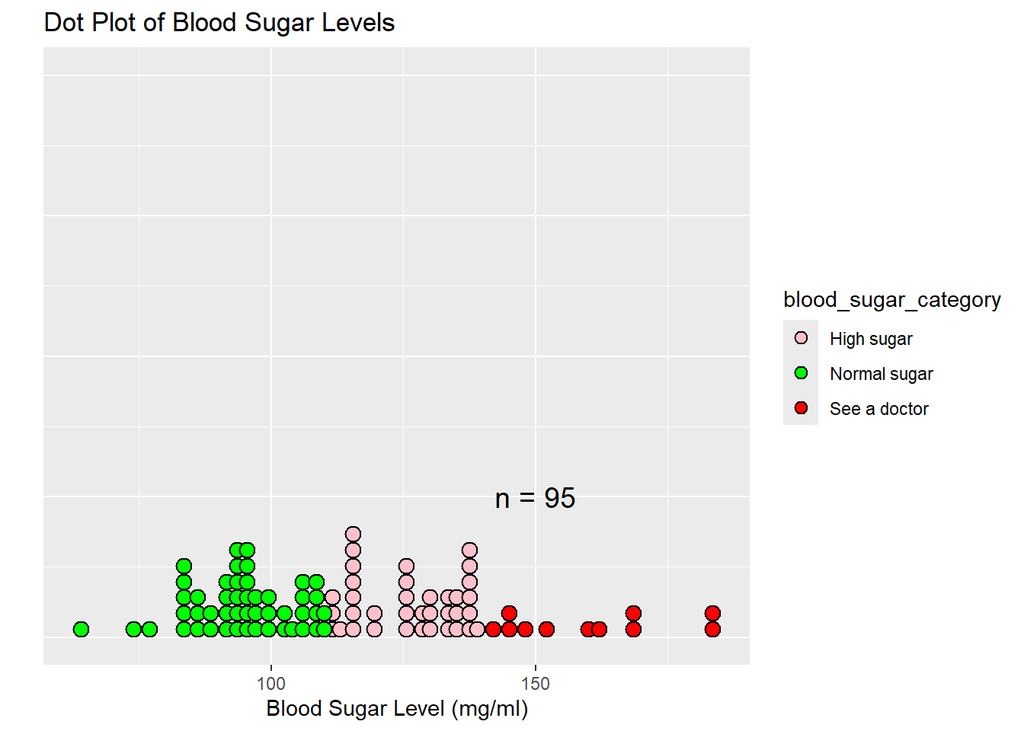

```r
## b. Dot plot of blood sugar levels
ggplot(sugar_data, aes(x = blood_sugar, fill = blood_sugar_category)) +
  geom_dotplot(binwidth = 2, dotsize = 1.5) +
  scale_fill_manual(values = c("Normal sugar" = "green", "High sugar" = "pink", "See a doctor" = "red"))+
  labs(title = "Dot Plot of Blood Sugar Levels", x = "Blood Sugar Level (mg/ml)", y = "") +
  theme(axis.text.y = element_blank(),  # Remove y-axis text
        axis.ticks.y = element_blank())+ # Remove y-axis ticks
  annotate("text", x = 150, y = 0.25, label = "n = 95", size = 5, color = "black")  # Position the "n = 95" inside the chart
```

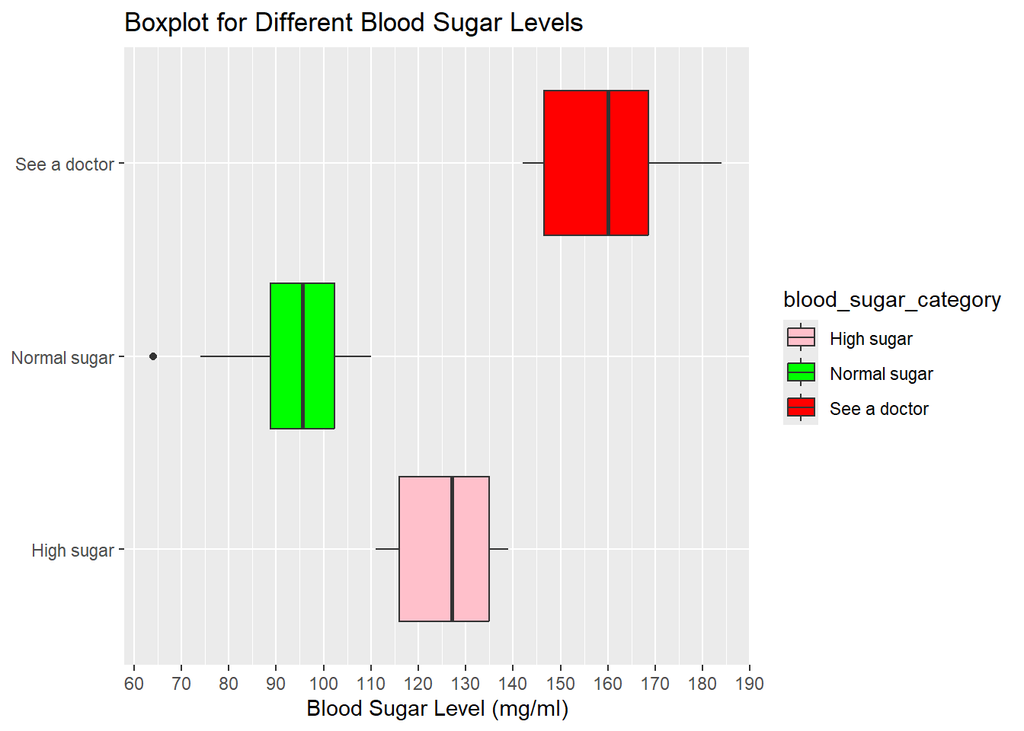

```r
## c. Boxplots for different blood sugar levels
ggplot(sugar_data, aes(x = blood_sugar_category, y = blood_sugar, fill = blood_sugar_category)) +
  geom_boxplot() +
  scale_y_continuous(breaks = seq(60, 200, by = 10)) +  # Set the x-axis breaks from 60 to 200 with steps of 10
  scale_fill_manual(values = c("Normal sugar" = "green", "High sugar" = "pink", "See a doctor" = "red")) +
  coord_flip() +
  labs(title = "Boxplot for Different Blood Sugar Levels", x = "Blood Sugar Category", y = "Blood Sugar Level (mg/ml)")+
  theme(axis.title.y = element_blank())
```

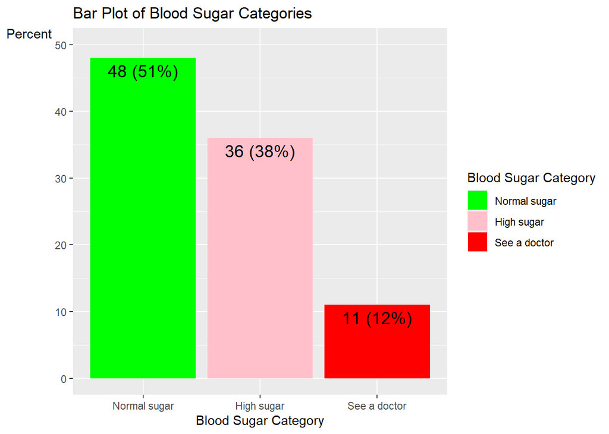

```r
## d. Bar plot for different blood sugar levels with y-axis title at the top and custom axis range
sugar_data$blood_sugar_category <- factor(sugar_data$blood_sugar_category,
  levels = c("Normal sugar", "High sugar", "See a doctor"))

# Calculate the percentages for each category
percent_data <- sugar_data %>%
  group_by(blood_sugar_category) %>%
  summarise(count = n()) %>%
  mutate(percent = (count / sum(count)) * 100)

ggplot(percent_data, aes(x = blood_sugar_category, y = count, fill = blood_sugar_category)) +
  geom_bar(stat = "identity") +
  geom_text(aes(label = paste0(count, " (", round(percent, 0), "%)")),  # Combine count and percentage
            vjust = 1.5,
            color = "black",
            size = 5) +
  scale_fill_manual(values = c("Normal sugar" = "green", "High sugar" = "pink", "See a doctor" = "red")) +
  labs(title = "Bar Plot of Blood Sugar Categories", x = "Blood Sugar Category", y = "Percent", fill = "Blood Sugar Category") +
  ylim(c(0, 50))+
  theme(axis.title.y = element_text(angle = 0, vjust = 1, hjust = 10))
```

e) The bar plot of blood sugar categories shows that the majority of individuals, 51%, have normal blood sugar levels, represented by 48 people. The second largest group, consisting of 36 people or 38%, has high blood sugar levels. A smaller group, 11 individuals or 12%, has blood sugar levels high enough to require consulting a doctor. This distribution indicates that more than half of the individuals fall within the normal range, while a significant portion has elevated blood sugar levels, with a small percentage requiring medical attention.

**Q2** Consider the `GDP.csv` dataset on Moodle, which contains Gross Domestic Product (GDP) for various countries. Answer the following questions:

[5+5+15=25 pts.]

1. Create a histogram based on the data.
2. Does your histogram appear symmetric? Comment on its shape.
3. Validate the Central Limit Theorem (CLT) as discussed in class. Share your findings while incorporating the key concepts of the CLT.

```r
gdp_data <- read.csv("GDP.csv", stringsAsFactors = FALSE)
head(gdp_data)
```

```
##          Country      gdp
## 1  United States 19417.14
## 2          China 11795.30
## 3          Japan  4841.22
## 4        Germany  3423.29
## 5 United Kingdom  2496.76
## 6          India  2454.46
```

# a. Create a histogram based on the data

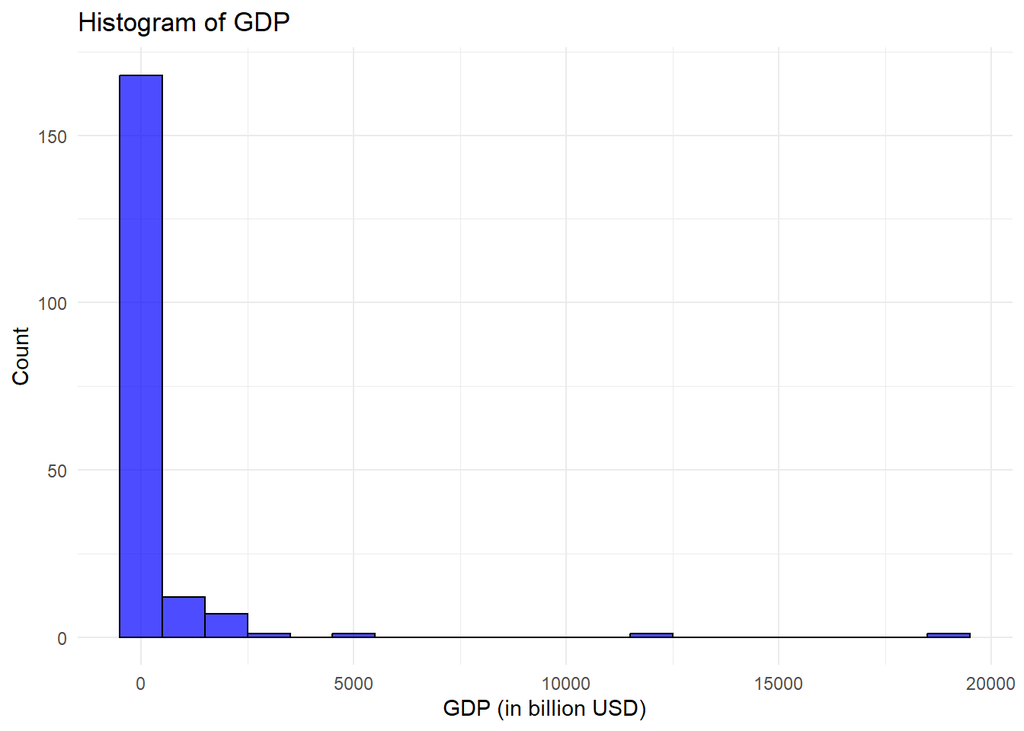

```r
ggplot(gdp_data, aes(x = gdp)) +
  geom_histogram(binwidth = 1000, fill = "blue", color = "black", alpha = 0.7) +
  labs(title = "Histogram of GDP", x = "GDP (in billion USD)", y = "Count") +
  theme_minimal()
```

# b. Comment on the histogram shape

The histogram does not appear symmetric. In fact, the distribution of GDP is highly right-skewed (positively skewed). Here’s a detailed explanation:

Shape of the Histogram:

Right-skewed: The majority of countries have relatively low GDP values, as seen in the tall bars on the left side of the histogram. These represent countries with smaller GDPs.

Long tail: There is a long tail stretching toward the right, indicating that a few countries have significantly higher GDP values. These countries are outliers in the data.

Skewness: The skewness is due to the presence of a few countries with very large GDPs (like the United States and China), which pull the distribution to the right, making it heavily right-skewed.

Summary: The histogram is not symmetric. The GDP distribution is heavily skewed to the right, where most of the data is concentrated on the left (lower GDP values), with a few extreme outliers on the far right representing countries with much higher GDPs. This indicates a significant disparity in GDP distribution among countries.

# c. Validate the Central Limit Theorem (CLT)

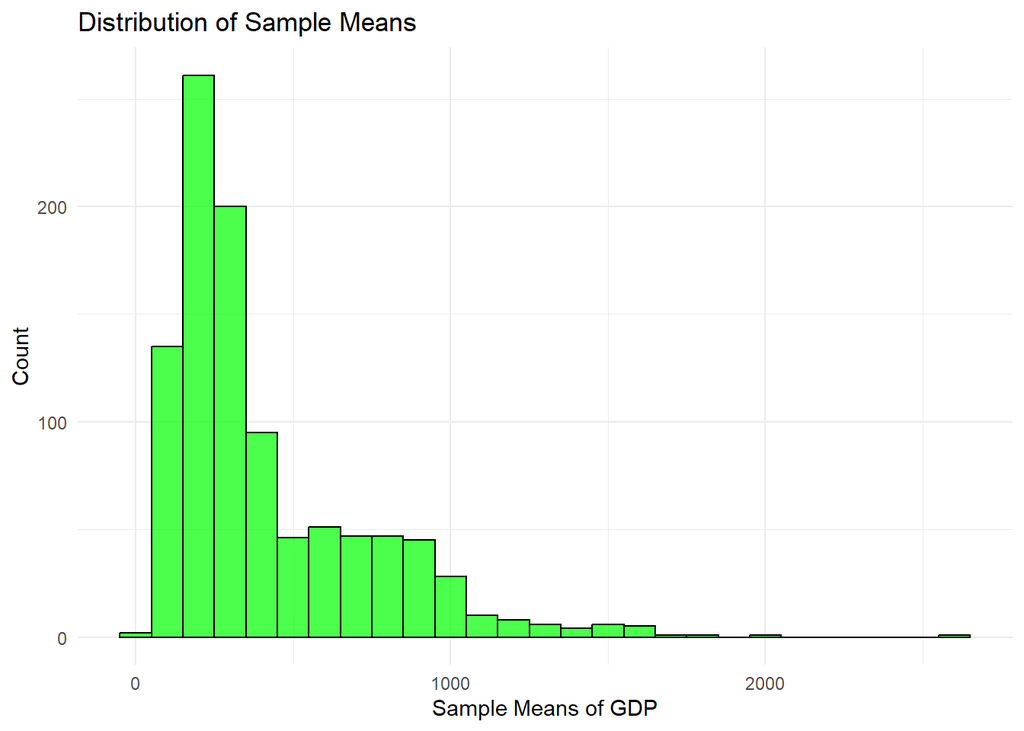

```r
set.seed(123)  # Ensure reproducibility
sample_means <- replicate(1000, mean(sample(gdp_data$gdp, size = 30, replace = TRUE)))

# Plot the distribution of sample means
ggplot(data.frame(sample_means), aes(x = sample_means)) +
  geom_histogram(binwidth = 100, fill = "green", color = "black", alpha = 0.7) +
  labs(title = "Distribution of Sample Means", x = "Sample Means of GDP", y = "Count") +
  theme_minimal()
```

# Findings and Validation of CLT: